# Diabetes Analysis Using Statistical Programming Project

Sivashankari Alaganandham

2024-08-13

Set a CRAN Mirror

```r
options(repos = c(CRAN = "https://cloud.r-project.org/"))
```

Install the Required Package

```r
install.packages("pscl")
```

Table of Variables

```r
# Load the openxlsx package
library(openxlsx)

# Load the knitr package
library(knitr)

# Read the entire sheet
variable <- read.xlsx("C:/Users/Dell/Desktop/Projects/Diabetes Analysis using Statistical Programming/VariableTable.xlsx", sheet = "Sheet1")

# View the data
kable(variable)
```

[output not shown]

Table of Summary Statistics

```r
# Load necessary packages
library(knitr)
library(dplyr)
library(tidyr)

# Read the dataset
data <- read.csv("C:/Users/Dell/Desktop/Projects/Diabetes Analysis using Statistical Programming/diabetes_dataset.csv")

# Function to calculate summary statistics
calc_summary_stats <- function(x) {
  c(
    Min = min(x, na.rm = TRUE),
    `1st Qu.` = quantile(x, 0.25, na.rm = TRUE),
    Median = median(x, na.rm = TRUE),
    Mean = mean(x, na.rm = TRUE),
    `3rd Qu.` = quantile(x, 0.75, na.rm = TRUE),
    Max = max(x, na.rm = TRUE)
  )
}

# Apply the function to each numeric variable in the dataset
summary_stats <- data %>%
  select_if(is.numeric) %>%
  summarise_all(list(calc_summary_stats))
# Unnest the list columns generated by summarise_all
summary_stats_unnested <- summary_stats %>%
  unnest(cols = everything(), names_repair = "minimal")

# Print the intermediate result to debug
# print(summary_stats_unnested)

# Transpose the summary statistics for better readability
summary_stats_t <- t(summary_stats_unnested)

# Convert the transposed summary stats into a data frame
summary_df <- as.data.frame(summary_stats_t)

# Set proper column names after transposing
colnames(summary_df) <- c("Min", "1st Qu.", "Median", "Mean", "3rd Qu.", "Max")

# Add the variable names as a separate column
summary_df$Variable <- rownames(summary_df)

# Reorder the columns to place the Variable column first
summary_df <- summary_df[, c("Variable", "Min", "1st Qu.", "Median", "Mean", "3rd Qu.", "Max")]

# Print the final summary_df to debug
print(summary_df)
```

```
##                                  Variable Min 1st Qu. Median        Mean
## Diabetes_binary           Diabetes_binary   0       0      0  0.13933302
## HighBP                             HighBP   0       0      0  0.42900110
## HighChol                         HighChol   0       0      0  0.42412094
## CholCheck                       CholCheck   0       1      1  0.96266950
## BMI                                   BMI  12      24     27 28.38236361
## Smoker                             Smoker   0       0      0  0.44316856
## Stroke                             Stroke   0       0      0  0.04057080
## HeartDiseaseorAttack HeartDiseaseorAttack   0       0      0  0.09418559
## PhysActivity                 PhysActivity   0       1      1  0.75654368
## Fruits                             Fruits   0       0      1  0.63425576
## Veggies                           Veggies   0       1      1  0.81141990
## HvyAlcoholConsump       HvyAlcoholConsump   0       0      0  0.05619678
## AnyHealthcare               AnyHealthcare   0       1      1  0.95105251
## NoDocbcCost                   NoDocbcCost   0       0      0  0.08417692
## GenHlth                           GenHlth   1       2      2  2.51139231
## MentHlth                         MentHlth   0       0      0  3.18477215
## PhysHlth                         PhysHlth   0       0      0  4.24208057
## DiffWalk                         DiffWalk   0       0      0  0.16822375
## Sex                                   Sex   0       0      0  0.44034216
## Age                                   Age   1       6      8  8.03211921
## Education                       Education   1       4      5  5.05043362
## Income                             Income   1       5      7  6.05387496
##                      3rd Qu. Max
## Diabetes_binary            0   1
## HighBP                     1   1
## HighChol                   1   1
## CholCheck                  1   1
## BMI                       31  98
## Smoker                     1   1
## Stroke                     0   1
## HeartDiseaseorAttack       0   1
## PhysActivity               1   1
## Fruits                     1   1
## Veggies                    1   1
## HvyAlcoholConsump          0   1
## AnyHealthcare              1   1
## NoDocbcCost                0   1
## GenHlth                    3   5
## MentHlth                   2  30
## PhysHlth                   3  30
## DiffWalk                   0   1
## Sex                        1   1
## Age                       10  13
## Education                  6   6
## Income                     8   8
```

```r
# Print the formatted summary statistics table
kable(summary_df, format = "latex", row.names = FALSE)
```

[output not shown]

```r
# Load necessary libraries
library(dplyr)
library(ggplot2)
library(MASS)
# Read the data set
data <- read.csv("C:/Users/Dell/Desktop/Projects/Diabetes Analysis using Statistical Programming/diabetes_dataset.csv")

# Convert relevant variables to categorical factors
data$HighBP <- factor(data$HighBP, levels = c(0, 1), labels = c("No High BP", "High BP"))
data$HighChol <- factor(data$HighChol, levels = c(0, 1), labels = c("No High Chol", "High Chol"))
data$PhysActivity <- factor(data$PhysActivity, levels = c(0, 1), labels = c("No", "Yes"))
data$Diabetes_binary <- factor(data$Diabetes_binary, levels = c(0, 1), labels = c("No Diabetes", "Diabetes or Pre-diabetes"))
```

Step 2: Descriptive Statistics (Summarise the data to get an understanding of the distribution) BMI

```r
# Load necessary library
library(dplyr)
library(knitr)

# Summary for numeric variable (BMI)
bmi_summary <- summary(data$BMI)

# Create a data frame for BMI summary
bmi_summary_df <- data.frame(
  Statistic = names(bmi_summary),
  BMI = as.numeric(bmi_summary)
)

# Numeric variable (BMI) summary table
kable(bmi_summary_df, caption = "Summary Statistics for BMI")
```

Summary Statistics for BMI

| Statistic | BMI |
| --- | --- |
| Min. | 12.00000 |
| 1st Qu. | 24.00000 |
| Median | 27.00000 |
| Mean | 28.38236 |
| 3rd Qu. | 31.00000 |
| Max. | 98.00000 |

High blood pressure

```r
summary(data$HighBP)
```

```
## No High BP    High BP
##     144851     108829
```

High cholesterol level

```r
summary(data$HighChol)
```

```
## No High Chol    High Chol
##       146089       107591
```

Physical activity

```r
summary(data$PhysActivity)
```

```
##     No    Yes
##  61760 191920
```

Diabetes Binary

```r
summary(data$Diabetes_binary)
```

```
##              No Diabetes Diabetes or Pre-diabetes
##                   218334                    35346
```

Step 3: Inferential Statistics - Chi Square Test for Categorical Variables Use of Chi Square Test is to evaluate the association between categorical variables (HighBP, HighChol, PhysActivity) and diabetes status.

```r
# Disable scientific notation
options(scipen=999)

# Chi-Square test for HighBP and Diabetes
chisq.test(data$HighBP, data$Diabetes_binary)
```

```
##
##  Pearson's Chi-squared test with Yates' continuity correction
##
## data:  data$HighBP and data$Diabetes_binary
## X-squared = 17562, df = 1, p-value < 0.00000000000000022
```

```r
# Chi-Square test for HighChol and Diabetes
chisq.test(data$HighChol, data$Diabetes_binary)
```

```
##
##  Pearson's Chi-squared test with Yates' continuity correction
##
## data:  data$HighChol and data$Diabetes_binary
## X-squared = 10174, df = 1, p-value < 0.00000000000000022
```

```r
# Chi-Square test for PhysActivity and Diabetes
chisq.test(data$PhysActivity, data$Diabetes_binary)
```

```
##
##  Pearson's Chi-squared test with Yates' continuity correction
##
## data:  data$PhysActivity and data$Diabetes_binary
## X-squared = 3539.4, df = 1, p-value < 0.00000000000000022
```

```r
# Re-enable scientific notation (optional)
options(scipen=0)
```

Step 4: Inferential Statistics - T-test for Continuous Variable For the continuous variable BMI, use a t-test to compare the means between the diabetes and non-diabetes groups.

```r
# Perform Welch Two Sample t-test
t_test_result <- t.test(data$BMI ~ data$Diabetes_binary)

# Extract components from the test result
t_statistic <- t_test_result$statistic
df <- t_test_result$parameter
p_value <- t_test_result$p.value
conf_int <- t_test_result$conf.int
mean_group1 <- t_test_result$estimate[1]
mean_group2 <- t_test_result$estimate[2]

# Formatting the output
cat("Welch Two Sample t-test\n\n")
```

```
## Welch Two Sample t-test
```

```r
cat("Data: `data$BMI` by `data$Diabetes_binary`\n\n")
```

```
## Data: `data$BMI` by `data$Diabetes_binary`
```

```r
cat(paste("t-statistic: ", round(t_statistic, 2), "\n", sep = ""))
```

```
## t-statistic: -99.92
```

```r
cat(paste("Degrees of freedom (df): ", round(df, 3), "\n", sep = ""))
```

```
## Degrees of freedom (df): 44093.403
```

```r
cat(paste("p-value: ", format.pval(p_value, digits = 20), "\n\n", sep = ""))
```

```
## p-value: < 2.22044604925031308e-16
```

```r
cat("Alternative Hypothesis:\n")
```

```
## Alternative Hypothesis:
```

```r
cat("The true difference in means between the group \"No Diabetes\" and the group \"Diabetes or Pre-diabetes\" is not equal to 0.\n\n")
```

```
## The true difference in means between the group "No Diabetes" and the group "Diabetes or Pre-diabetes" is not equal to 0.
```

```r
cat("95% Confidence Interval:\n")
```

```
## 95% Confidence Interval:
```

```r
cat(paste("• Lower bound: ", round(conf_int[1], 6), "\n", sep = ""))
```

```
## • Lower bound: -4.219416
```

```r
cat(paste("• Upper bound: ", round(conf_int[2], 6), "\n\n", sep = ""))
```

```
## • Upper bound: -4.057065
```

```r
cat("Sample Estimates:\n")
```

```
## Sample Estimates:
```

```r
cat(paste("• Mean BMI in the \"No Diabetes\" group: ", round(mean_group1, 5), "\n", sep = ""))
```

```
## • Mean BMI in the "No Diabetes" group: 27.80577
```

```r
cat(paste("• Mean BMI in the \"Diabetes or Pre-diabetes\" group: ", round(mean_group2, 5), "\n", sep = ""))
```

```
## • Mean BMI in the "Diabetes or Pre-diabetes" group: 31.94401
```

Step 5: Logistic Regression Conduct logistic regression to model the likelihood of diabetes based on the health-related factors.

```r
# Logistic Regression Model
logit_model <- glm(Diabetes_binary ~ BMI + HighBP + HighChol + PhysActivity, data = data, family = binomial)

# Summary of the model
summary(logit_model)
```

```
##
## Call:
## glm(formula = Diabetes_binary ~ BMI + HighBP + HighChol + PhysActivity,
##     family = binomial, data = data)
##
## Coefficients:
##                     Estimate Std. Error z value Pr(>|z|)
## (Intercept)       -4.4642583  0.0304750 -146.49   <2e-16 ***
## BMI                0.0603542  0.0008332   72.43   <2e-16 ***
## HighBPHigh BP      1.2308447  0.0138182   89.07   <2e-16 ***
## HighCholHigh Chol  0.8104395  0.0129862   62.41   <2e-16 ***
## PhysActivityYes   -0.4005633  0.0131252  -30.52   <2e-16 ***
## ---
## Signif. codes:  0 '***' 0.001 '**' 0.01 '*' 0.05 '.' 0.1 ' ' 1
##
## (Dispersion parameter for binomial family taken to be 1)
##
##     Null deviance: 204847  on 253679  degrees of freedom
## Residual deviance: 175945  on 253675  degrees of freedom
## AIC: 175955
##
## Number of Fisher Scoring iterations: 5
```

```r
# Odds Ratios
exp(coef(logit_model))
```

```
##       (Intercept)               BMI     HighBPHigh BP HighCholHigh Chol
##        0.01151323        1.06221267        3.42412055        2.24889622
##   PhysActivityYes
##        0.66994254
```

**OBJECTIVE 2** Determine the predictive power of lifestyle behaviors on diabetes risk Step 1: Data Preparation

```r
# Load necessary libraries
library(dplyr)

# Load the dataset
data <- read.csv("C:/Users/Dell/Desktop/Projects/Diabetes Analysis using Statistical Programming/diabetes_dataset.csv")

# Convert variables to appropriate data types
data$Diabetes_binary <- as.factor(data$Diabetes_binary)
data$Smoker <- as.factor(data$Smoker)
data$HvyAlcoholConsump <- as.factor(data$HvyAlcoholConsump)
data$MentHlth <- as.integer(data$MentHlth)

# View summary of the dataset
summary(data)
```

```
##  Diabetes_binary     HighBP         HighChol        CholCheck
##  0:218334        Min.   :0.000   Min.   :0.0000   Min.   :0.0000
##  1: 35346        1st Qu.:0.000   1st Qu.:0.0000   1st Qu.:1.0000
##                  Median :0.000   Median :0.0000   Median :1.0000
##                  Mean   :0.429   Mean   :0.4241   Mean   :0.9627
##                  3rd Qu.:1.000   3rd Qu.:1.0000   3rd Qu.:1.0000
##                  Max.   :1.000   Max.   :1.0000   Max.   :1.0000
##       BMI        Smoker         Stroke        HeartDiseaseorAttack
##  Min.   :12.00   0:141257   Min.   :0.00000   Min.   :0.00000
##  1st Qu.:24.00   1:112423   1st Qu.:0.00000   1st Qu.:0.00000
##  Median :27.00              Median :0.00000   Median :0.00000
##  Mean   :28.38              Mean   :0.04057   Mean   :0.09419
##  3rd Qu.:31.00              3rd Qu.:0.00000   3rd Qu.:0.00000
##  Max.   :98.00              Max.   :1.00000   Max.   :1.00000
##   PhysActivity        Fruits          Veggies       HvyAlcoholConsump
##  Min.   :0.0000   Min.   :0.0000   Min.   :0.0000   0:239424
##  1st Qu.:1.0000   1st Qu.:0.0000   1st Qu.:1.0000   1: 14256
##  Median :1.0000   Median :1.0000   Median :1.0000
##  Mean   :0.7565   Mean   :0.6343   Mean   :0.8114
##  3rd Qu.:1.0000   3rd Qu.:1.0000   3rd Qu.:1.0000
##  Max.   :1.0000   Max.   :1.0000   Max.   :1.0000
##  AnyHealthcare     NoDocbcCost         GenHlth         MentHlth
##  Min.   :0.0000   Min.   :0.00000   Min.   :1.000   Min.   : 0.000
##  1st Qu.:1.0000   1st Qu.:0.00000   1st Qu.:2.000   1st Qu.: 0.000
##  Median :1.0000   Median :0.00000   Median :2.000   Median : 0.000
##  Mean   :0.9511   Mean   :0.08418   Mean   :2.511   Mean   : 3.185
##  3rd Qu.:1.0000   3rd Qu.:0.00000   3rd Qu.:3.000   3rd Qu.: 2.000
##  Max.   :1.0000   Max.   :1.00000   Max.   :5.000   Max.   :30.000
##     PhysHlth         DiffWalk           Sex              Age
##  Min.   : 0.000   Min.   :0.0000   Min.   :0.0000   Min.   : 1.000
##  1st Qu.: 0.000   1st Qu.:0.0000   1st Qu.:0.0000   1st Qu.: 6.000
##  Median : 0.000   Median :0.0000   Median :0.0000   Median : 8.000
##  Mean   : 4.242   Mean   :0.1682   Mean   :0.4403   Mean   : 8.032
##  3rd Qu.: 3.000   3rd Qu.:0.0000   3rd Qu.:1.0000   3rd Qu.:10.000
##  Max.   :30.000   Max.   :1.0000   Max.   :1.0000   Max.   :13.000
##    Education        Income
##  Min.   :1.00   Min.   :1.000
##  1st Qu.:4.00   1st Qu.:5.000
##  Median :5.00   Median :7.000
##  Mean   :5.05   Mean   :6.054
##  3rd Qu.:6.00   3rd Qu.:8.000
##  Max.   :6.00   Max.   :8.000
```

Step 2: Logistic Regression

```r
# Logistic regression model
model <- glm(Diabetes_binary ~ Smoker + HvyAlcoholConsump + MentHlth, data = data, family = binomial)

# Summary of the model
summary(model)
```

```
##
## Call:
## glm(formula = Diabetes_binary ~ Smoker + HvyAlcoholConsump +
##     MentHlth, family = binomial, data = data)
##
## Coefficients:
##                      Estimate Std. Error z value Pr(>|z|)
## (Intercept)        -2.0246204  0.0085046 -238.06   <2e-16 ***
## Smoker1             0.3552459  0.0116197   30.57   <2e-16 ***
## HvyAlcoholConsump1 -1.1015695  0.0363746  -30.28   <2e-16 ***
## MentHlth            0.0216547  0.0006754   32.06   <2e-16 ***
## ---
## Signif. codes:  0 '***' 0.001 '**' 0.01 '*' 0.05 '.' 0.1 ' ' 1
##
## (Dispersion parameter for binomial family taken to be 1)
##
##     Null deviance: 204847  on 253679  degrees of freedom
## Residual deviance: 201755  on 253676  degrees of freedom
## AIC: 201763
##
## Number of Fisher Scoring iterations: 5
```

Step 3: Interpretation of Results

```r
# Calculate Odds Ratios
exp(coef(model))
```

```
##        (Intercept)            Smoker1 HvyAlcoholConsump1           MentHlth
##          0.1320440          1.4265314          0.3323491          1.0218908
```

```r
# Confidence Intervals for Odds Ratios
exp(confint(model))
```

```
##                        2.5 %    97.5 %
## (Intercept)        0.1298570 0.1342591
## Smoker1            1.3944130 1.4593952
## HvyAlcoholConsump1 0.3092607 0.3566628
## MentHlth           1.0205359 1.0232416
```

**OBJECTIVE 3** Analyze the influence of socioeconomic factors on diabetes prevalence Step 1: Data Preparation Converting numerical variables into categorical variables Ensure that your data is properly loaded and the categorical variables are correctly defined

```r
# Converting 'Age' variable into categorical variable
data$Age <- factor(data$Age,
                      levels = c(1, 2, 3, 4, 5, 6, 7, 8, 9, 10, 11, 12, 13), # the numeric codes in order
                      labels = c("Age 18 - 24",
                                 "Age 25 - 29",
                                 "Age 30 - 34",
                                 "Age 35 - 39",
                                 "Age 40 - 44",
                                 "Age 45 - 49",
                                 "Age 50 - 54",
                                 "Age 55 - 59",
                                 "Age 60 - 64",
                                 "Age 65 - 69",
                                 "Age 70 - 74",
                                 "Age 75 - 79",
                                 "Age 80 or older"),
                      ordered = TRUE) # Specify that this is an ordinal factor

# Converting 'Education' variable into categorical variable
data$Education <- factor(data$Education,
                      levels = c(1, 2, 3, 4, 5, 6), # the numeric codes in order
                      labels = c("Never attended school or only kindergarten",
                                 "Grades 1 - 8 (Elementary)",
                                 "Grades 9 - 11 (Some high school)",
                                 "Grade 12 or GED (High school graduate)",
                                 "College 1 year to 3 years (Some college or technical school)",
                                 "College 4 years or more (College graduate)"),
                      ordered = TRUE) # Specify that this is an ordinal factor

# Converting 'Income' variable into categorical variable
data$Income <- factor(data$Income,
                      levels = c(1, 2, 3, 4, 5, 6, 7, 8), # the numeric codes in order
                      labels = c("Less than $10,000",
                                 "$10,000 to $15,000",
                                 "$15,000 to $20,000",
                                 "$20,000 to $25,000",
                                 "$25,000 to $35,000",
                                 "$35,000 to $50,000",
                                 "$50,000 to $75,000",
                                 "$75,000 or more"),
                      ordered = TRUE) # Specify that this is an ordinal factor

# levels: defines the order of the numeric codes as they appear in the data
# labels: defines the corresponding category labels that replace the numeric codes
# ordered = TRUE: specifies that the variable is ordinal, meaning that the order of the levels matters.
```

Step 2: Perform EDA Perform some basic EDA to understand the distribution of your variables.

```r
summary(data)
```

```
##  Diabetes_binary     HighBP         HighChol        CholCheck
##  0:218334        Min.   :0.000   Min.   :0.0000   Min.   :0.0000
##  1: 35346        1st Qu.:0.000   1st Qu.:0.0000   1st Qu.:1.0000
##                  Median :0.000   Median :0.0000   Median :1.0000
##                  Mean   :0.429   Mean   :0.4241   Mean   :0.9627
##                  3rd Qu.:1.000   3rd Qu.:1.0000   3rd Qu.:1.0000
##                  Max.   :1.000   Max.   :1.0000   Max.   :1.0000
##
##       BMI        Smoker         Stroke        HeartDiseaseorAttack
##  Min.   :12.00   0:141257   Min.   :0.00000   Min.   :0.00000
##  1st Qu.:24.00   1:112423   1st Qu.:0.00000   1st Qu.:0.00000
##  Median :27.00              Median :0.00000   Median :0.00000
##  Mean   :28.38              Mean   :0.04057   Mean   :0.09419
##  3rd Qu.:31.00              3rd Qu.:0.00000   3rd Qu.:0.00000
##  Max.   :98.00              Max.   :1.00000   Max.   :1.00000
##
##   PhysActivity        Fruits          Veggies       HvyAlcoholConsump
##  Min.   :0.0000   Min.   :0.0000   Min.   :0.0000   0:239424
##  1st Qu.:1.0000   1st Qu.:0.0000   1st Qu.:1.0000   1: 14256
##  Median :1.0000   Median :1.0000   Median :1.0000
##  Mean   :0.7565   Mean   :0.6343   Mean   :0.8114
##  3rd Qu.:1.0000   3rd Qu.:1.0000   3rd Qu.:1.0000
##  Max.   :1.0000   Max.   :1.0000   Max.   :1.0000
##
##  AnyHealthcare     NoDocbcCost         GenHlth         MentHlth
##  Min.   :0.0000   Min.   :0.00000   Min.   :1.000   Min.   : 0.000
##  1st Qu.:1.0000   1st Qu.:0.00000   1st Qu.:2.000   1st Qu.: 0.000
##  Median :1.0000   Median :0.00000   Median :2.000   Median : 0.000
##  Mean   :0.9511   Mean   :0.08418   Mean   :2.511   Mean   : 3.185
##  3rd Qu.:1.0000   3rd Qu.:0.00000   3rd Qu.:3.000   3rd Qu.: 2.000
##  Max.   :1.0000   Max.   :1.00000   Max.   :5.000   Max.   :30.000
##
##     PhysHlth         DiffWalk           Sex                  Age
##  Min.   : 0.000   Min.   :0.0000   Min.   :0.0000   Age 60 - 64:33244
##  1st Qu.: 0.000   1st Qu.:0.0000   1st Qu.:0.0000   Age 65 - 69:32194
##  Median : 0.000   Median :0.0000   Median :0.0000   Age 55 - 59:30832
##  Mean   : 4.242   Mean   :0.1682   Mean   :0.4403   Age 50 - 54:26314
##  3rd Qu.: 3.000   3rd Qu.:0.0000   3rd Qu.:1.0000   Age 70 - 74:23533
##  Max.   :30.000   Max.   :1.0000   Max.   :1.0000   Age 45 - 49:19819
##                                                     (Other)    :87744
##                                                         Education
##  Never attended school or only kindergarten                  :   174
##  Grades 1 - 8 (Elementary)                                   :  4043
##  Grades 9 - 11 (Some high school)                            :  9478
##  Grade 12 or GED (High school graduate)                      : 62750
##  College 1 year to 3 years (Some college or technical school): 69910
##  College 4 years or more (College graduate)                  :107325
##
##                 Income
##  $75,000 or more   :90385
##  $50,000 to $75,000:43219
##  $35,000 to $50,000:36470
##  $25,000 to $35,000:25883
##  $20,000 to $25,000:20135
##  $15,000 to $20,000:15994
##  (Other)           :21594
```

```r
table(data$Diabetes) # Assuming 'Diabetes' is your dependent variable
```

```
##
##      0      1
## 218334  35346
```

Step 3: Logistic Regression Model Fit a logistic regression model with Age, Education, and Income as independent variables.

```r
# Logistic regression model
model <- glm(Diabetes_binary ~ Age + Education + Income, data = data, family = binomial)

# Display the summary of the model
summary(model)
```

```
##
## Call:
## glm(formula = Diabetes_binary ~ Age + Education + Income, family = binomial,
##     data = data)
##
## Coefficients:
##              Estimate Std. Error z value Pr(>|z|)
## (Intercept) -1.962761   0.032656 -60.103  < 2e-16 ***
## Age.L        3.345659   0.064475  51.891  < 2e-16 ***
## Age.Q       -1.377806   0.062734 -21.963  < 2e-16 ***
## Age.C       -0.176103   0.058365  -3.017  0.00255 **
## Age^4       -0.075654   0.055552  -1.362  0.17325
## Age^5       -0.122838   0.053121  -2.312  0.02075 *
## Age^6        0.078028   0.049657   1.571  0.11610
## Age^7        0.046242   0.045364   1.019  0.30803
## Age^8       -0.018255   0.040371  -0.452  0.65114
## Age^9       -0.005971   0.035245  -0.169  0.86547
## Age^10      -0.033214   0.030324  -1.095  0.27338
## Age^11       0.011739   0.026200   0.448  0.65411
## Age^12       0.024501   0.022057   1.111  0.26665
## Education.L -0.558704   0.106967  -5.223 1.76e-07 ***
## Education.Q -0.085408   0.097353  -0.877  0.38033
## Education.C  0.014930   0.069232   0.216  0.82926
## Education^4 -0.087570   0.040830  -2.145  0.03197 *
## Education^5 -0.057343   0.023476  -2.443  0.01458 *
## Income.L    -1.002555   0.020669 -48.504  < 2e-16 ***
## Income.Q    -0.152429   0.019183  -7.946 1.93e-15 ***
## Income.C    -0.017431   0.018384  -0.948  0.34305
## Income^4    -0.080095   0.018324  -4.371 1.24e-05 ***
## Income^5    -0.020039   0.018035  -1.111  0.26653
## Income^6    -0.045036   0.017641  -2.553  0.01068 *
## Income^7     0.006574   0.017410   0.378  0.70573
## ---
## Signif. codes:  0 '***' 0.001 '**' 0.01 '*' 0.05 '.' 0.1 ' ' 1
##
## (Dispersion parameter for binomial family taken to be 1)
##
##     Null deviance: 204847  on 253679  degrees of freedom
## Residual deviance: 188474  on 253655  degrees of freedom
## AIC: 188524
##
## Number of Fisher Scoring iterations: 6
```

Step 4: Assessing Model Fit Evaluate the model fit using various metrics like AIC, and perform goodness-of-fit tests.

```r
# AIC (Akaike Information Criterion)
AIC(model)
```

```
## [1] 188524
```

```r
# Install package
install.packages("pscl")
# McFadden's R-squared
library(pscl)
pR2(model)
```

```
## fitting null model for pseudo-r2
```

```
##           llh       llhNull            G2      McFadden          r2ML
## -9.423700e+04 -1.024235e+05  1.637305e+04  7.992818e-02  6.250339e-02
##          r2CU
##  1.128161e-01
```

Step 5: Odds Ratio Calculate the odds ratios for easier interpretation of the coefficients.

```r
exp(coef(model))
```

```
## (Intercept)       Age.L       Age.Q       Age.C       Age^4       Age^5
##   0.1404701  28.3792598   0.2521312   0.8385314   0.9271372   0.8844073
##       Age^6       Age^7       Age^8       Age^9      Age^10      Age^11
##   1.0811526   1.0473283   0.9819110   0.9940466   0.9673316   1.0118082
##      Age^12 Education.L Education.Q Education.C Education^4 Education^5
##   1.0248041   0.5719500   0.9181378   1.0150421   0.9161544   0.9442702
##    Income.L    Income.Q    Income.C    Income^4    Income^5    Income^6
##   0.3669406   0.8586201   0.9827201   0.9230285   0.9801608   0.9559634
##    Income^7
##   1.0065955
```

Step 6: Model Diagnostics Check for multicollinearity and influential observations.

```r
# install package required
install.packages("car")
# Variance Inflation Factor (VIF)
library(car)
vif(model)
```

```
##               GVIF Df GVIF^(1/(2*Df))
## Age       1.075268 12        1.003028
## Education 1.315598  5        1.027809
## Income    1.379142  7        1.023227
```

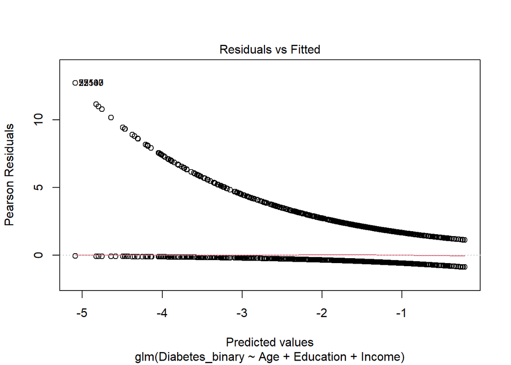

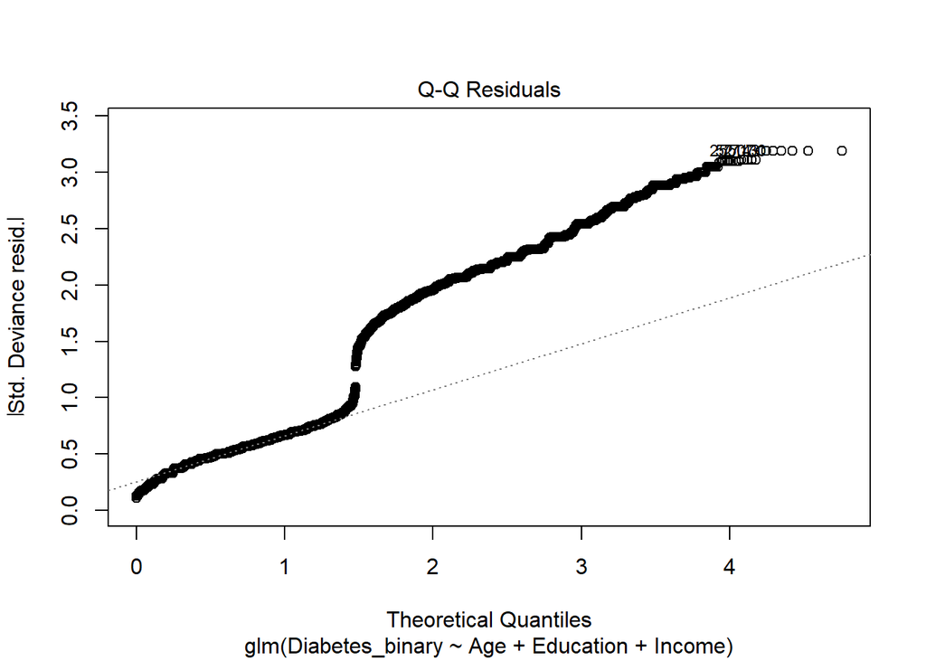

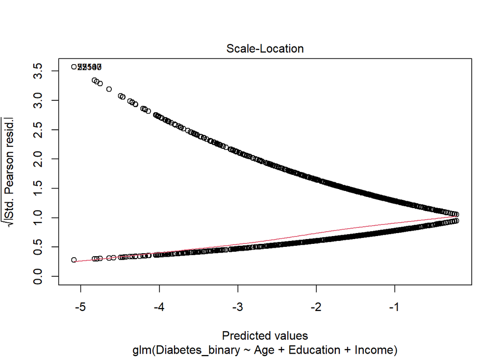

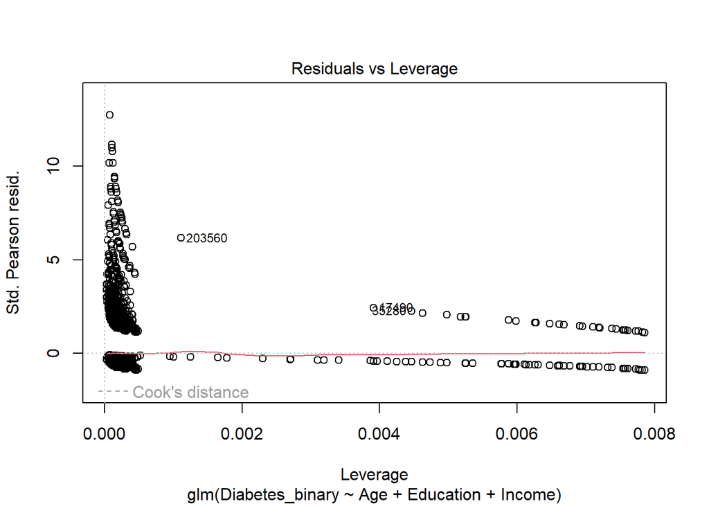

```r
# Check residuals and leverage
plot(model)
```

Step 7: Prediction and Validation Make predictions and assess the model’s predictive power.

```r
# Predicted probabilities
data$predicted_prob <- predict(model, type = "response")

# Classification table
table(data$Diabetes, data$predicted_prob > 0.5)
```

```
##
##      FALSE
##   0 218334
##   1  35346
```

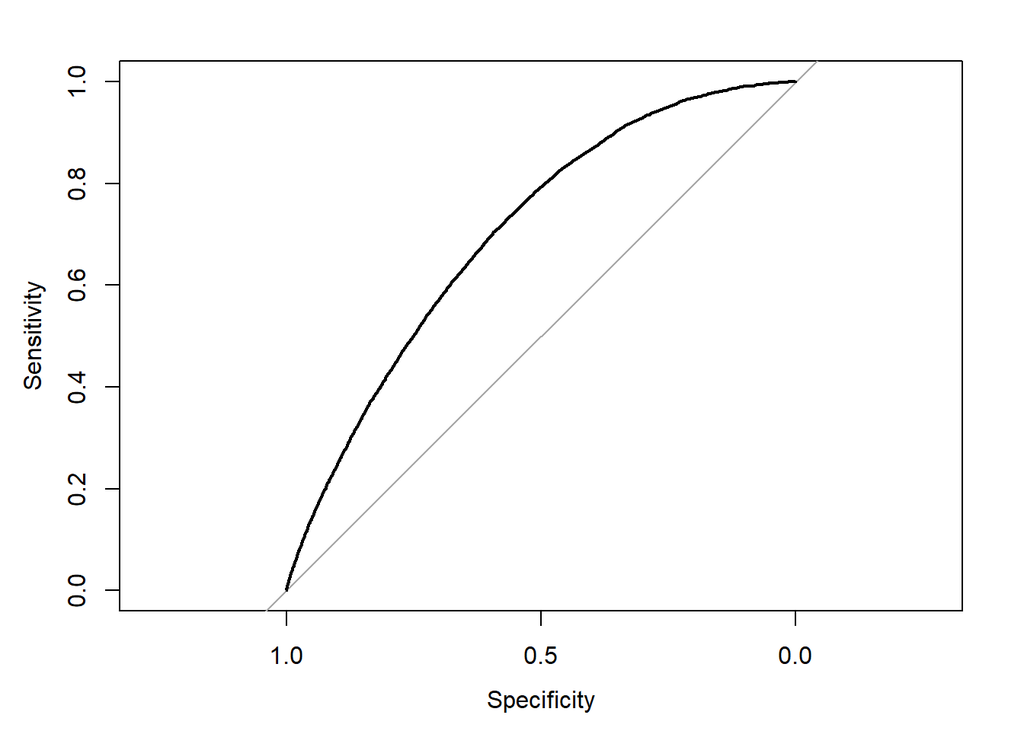

```r
# ROC curve and AUC
install.packages("pROC")
library(pROC)
roc_curve <- roc(data$Diabetes, data$predicted_prob)
plot(roc_curve)
```

```r
auc(roc_curve)
```

```
## Area under the curve: 0.7021
```